# Home Field Advantage

Zihan Fang

9/26/2020

## 0.1 Introduction

**If home field advantage exists, how much of an impact does it have on winning the world series?**

**In this blog, I will use simulation and analytic probability calculations to answer a series of questions related to the World Series. I will also take data science concepts and will explain the question and explain the solution and my assumptions of solutions.**

## 0.2 Background

**The home field advantage is the edge which a team may have when playing a game at its home stadium. For example, it is the edge the Braves may have over the Yankees when the head-to-head match-up is in Atlanta. It is the advantage the Yankees may have when the head-to-head match-up is in New York.**

**The World Series is a first-to-4-wins match-up between the champions of the American and National Leagues of Major League Baseball. In this assignment, you are going to use simulation and analytic methods to compare the probability of winning the World Series with and without home field advantage.**

**Setup:**

**Suppose that the Braves and the Yankees are teams competing in the World Series.**

**The table below has the two possible schedules for each game of the series. (NYC = New York City, ATL = Atlanta)**

| Overall advantage | Game 1 | Game 2 | Game 3 | Game 4 | Game 5 | Game 6 | Game 7 |
| --- | --- | --- | --- | --- | --- | --- | --- |
| Braves | ATL | ATL | NYC | NYC | NYC | ATL | ATL |
| Yankees | NYC | NYC | ATL | ATL | ATL | NYC | NYC |

**Let P<sub>B</sub> be the probability that the Braves win a single head-to-head match-up with the Yankees, under the assumption that home field advantage doesn’t exist. Let PBH denote the probability that the Braves win a single head-to-head match-up with the Yankees as the home team (H for home). Let PBA denote the probability that the Braves win a single head-to-head match-up with the away team (A for away).**

| Game location | No advantage | Advantage |
| --- | --- | --- |
| ATL | P<sub>B</sub> | P<sub>B</sub><sup>H</sup> = P<sub>B</sub>*1.1 |
| NYC | P<sub>B</sub> | P<sub>B</sub><sup>A</sup> = 1−(1−P<sub>B</sub>)*1.1 |

## 0.3 Methods

**1. Compute analytically the probability that the Braves win the world series when the sequence of game locations is {NYC, NYC, ATL, ATL, ATL, NYC, NYC}. (The code below computes the probability for the alternative sequence of game locations. Note: The code uses data.table syntax, which may be new to you. This is intential, as a gentle way to introduce data.table.) Calculate the probability with and without home field advantage when P<sub>B</sub>=0.55. What is the difference in probabilities?**

In this question, for example, the probability that the Braves win the world series in 4 games with advantages when the sequence of game locations is {NYC, NYC, ATL, ATL, ATL, NYC, NYC} will be P<sub>B</sub><sup>A</sup> * P<sub>B</sub><sup>A</sup> * P<sub>B</sub><sup>H</sup> * P<sub>B</sub><sup>H</sup>. Similarly, the probability that the Braves win the world series in 4 games without advantages in such a sequence could be (P<sub>B</sub>)<sup>4</sup>.

So, to get the overall probability of Braves win the world series(which means they may win in 4, 5, 6, 7 games), We will write a function to calculate the probability of each possible outcome and sum up the probability for wins as analytical probability that the Braves win the world series.

First, we require packages and import data we need.

```r
require(dplyr)
require(data.table)
# Get all possible outcomes
apo <- fread("all-possible-world-series-outcomes.csv")
```

Then, we set 0 as game played in NYC, 1 as game played in ATL and hfi stands for the sequence of game places. `pb` is P<sub>B</sub> which equals 0.55. `advantage_multiplier` stands for advantage, `advantage_multiplier=1` means no advantage, `advantage_multiplier=1.1` means winning with advantage. `pba` stands for P<sub>B</sub><sup>A</sup> and `pbh` stands for P<sub>B</sub><sup>H</sup>.

```r
# Home field indicator
# hfi <- c(1,1,0,0,0,1,1)  # {ATL, ATL, NYC, NYC, NYC, ATL, ATL}
hfi <- c(0,0,1,1,1,0,0) # {NYC, NYC, ATL, ATL, ATL, NYC, NYC}

# P_B pb <- 0.55
# Set = 1 for no advantage
# advantage_multiplier <- 1.1
# pbh <- 0.55*advantage_multiplier
# pba <- 1 - (1 - 0.55)*advantage_multiplier


world_series<- function(hfi=c(0,0,1,1,1,0,0),pb=0.55,advantage_multiplier=1.1){
pbh <- 0.55*advantage_multiplier
pba <- 1 - (1 - 0.55)*advantage_multiplier

# Calculate the probability of each possible outcome

apo[, p := NA_real_] # Initialize new column in apo to store prob
for(i in 1:nrow(apo)){
  prob_game <- rep(1, 7)
  for(j in 1:7){
    p_win <- ifelse(hfi[j], pbh, pba)
    prob_game[j] <- case_when(
        apo[i,j,with=FALSE] == "W" ~ p_win
      , apo[i,j,with=FALSE] == "L" ~ 1 - p_win
      , TRUE ~ 1
    )
  }
  apo[i, p := prod(prob_game)] # Data.table syntax
}

# Sanity check: does sum(p) == 1?
apo[, sum(p)] # This is data.table notation

# Probability of overall World Series outcomes
apo[, sum(p), overall_outcome]
}
```

Now, we use the function `world_series` to calculate the probability of Braves win World Series with advantage. `hfi=c(0,0,1,1,1,0,0)` means the sequence of game locations is {NYC, NYC, ATL, ATL, ATL, NYC, NYC}, and `advantage_multiplier=1.1` means Braves win the World Series with advantage. We get the answer 0.604221 .

```r
world_series(hfi=c(0,0,1,1,1,0,0),advantage_multiplier=1.1)
```

```
##    overall_outcome       V1
## 1:               W 0.604221
## 2:               L 0.395779
```

Again, we use the function `world_series` to calculate the probability of Braves win World Series with no advantage. `hfi=c(0,0,1,1,1,0,0)` also means the sequence of game locations is {NYC, NYC, ATL, ATL, ATL, NYC, NYC}, and `advantage_multiplier=1` means Braves win the World Series with no advantage. *We get the answer 0.6082878.*

```r
world_series(hfi=c(0,0,1,1,1,0,0),advantage_multiplier=1)
```

```
##    overall_outcome        V1
## 1:               W 0.6082878
## 2:               L 0.3917122
```

*The difference in probabilities is -0.004066825.*

```r
world_series(hfi=c(0,0,1,1,1,0,0),advantage_multiplier=1.1)$V1[1]-world_series(hfi=c(0,0,1,1,1,0,0),advantage_multiplier=1)$V1[1]
```

```
## [1] -0.004066825
```

In this sequence of game locations{NYC, NYC, ATL, ATL, ATL, NYC, NYC}, Yankees could play one more game in their home city than Braves, so under the assumption of home advantage Yankees has more overall home advantage. And that is why we can see the difference in probabilities with and without home advantage for Braves is negative.

**2. Calculate the same probabilities as the previous question by simulation.**

For this queation, we have to use simulation to compute the probability that Braves win the World Series. In this simulation, we generate the results that could be win or lose for 7 games randomly. If Braves win equal to or more than 4 games, the winner of World Series will be Braves. Otherwise, Braves will lose the World Series.

First, we set up the simulation. I will also create a function named `sim_world_series` to compute the probability, the function will return us one possible result for World Series in this sequence{NYC, NYC, ATL, ATL, ATL, NYC, NYC} every time we run it.

```r
hfi <- c(0,0,1,1,1,0,0)
sim_world_series <-
  function(hfi = c(1, 1, 0, 0, 0, 1, 1),
           pb = 0.55,
           advantage_multiplier = 1.1) {
    pbh <- 0.55 * advantage_multiplier
    pba <- 1 - (1 - 0.55) * advantage_multiplier
    win_n = 0
    for (i in 1:7) {
      if (hfi[i]){
        p_win = pbh
      } else{
        p_win = pba
      }
      game_l = rbinom(1, 1, p_win)
      win_n = game_l + win_n

      if (win_n == 4 | (i - win_n == 4))
        break
    }
    return(win_n == 4)
  }
```

Then, to get a more accurate probability that Braves win the World Series, we have to run the simulation 100,000 times. The final probability that Braves win the World Series will be the ratio that Braves wins among the 100,000 results.

*If Braves win with advantage, the probability will be*

```r
sim_win=NA
for(i in 1:100000){
  sim_win[i]=sim_world_series(hfi = c(0,0,1,1,1,0,0))
}
mean(sim_win)
```

```
## [1] 0.60538
```

*If Braves win with no advantage, the probability will be*

```r
sim_noa_win=NA
for(i in 1:100000){
sim_noa_win[i]=sim_world_series(hfi = c(0,0,1,1,1,0,0) , advantage_multiplier=1)
}
mean(sim_noa_win)
```

```
## [1] 0.60781
```

**3. What is the absolute and relative error for your simulation in the previous question?**

Based on Monte Carlo Error method, we know that the simulation produces an approximate answer and there is some degree of error in the number estimated by the Monte Carlo simulation. Intuitively, as the number of simulation repetitions increases, the degree of error should decrease. Calculate error as:

```
absolute error=|p̂−p|
relative error=|p̂−p|/p
```

So, the p̂ is the probability we calculated in simulation (question 2) and p is the analytical probability we calculated in first question. *Based on the formula, we can get the absolute error with the assumption that Braves win the World Series with advantage is*

```r
# absolute error
abs(mean(sim_win) - world_series(hfi = c(0, 0, 1, 1, 1, 0, 0))$V1[1])
```

```
## [1] 0.001159028
```

*We can get the relative error with the assumption that Braves win the World Series with advantage is*

```r
# relative error
abs(mean(sim_win) - world_series(hfi = c(0, 0, 1, 1, 1, 0, 0))$V1[1]) / world_series(hfi = c(0, 0, 1, 1, 1, 0, 0))$V1[1]
```

```
## [1] 0.001918219
```

*We can get the absolute error with the assumption that Braves win the World Series with no advantage is*

```r
# absolute error
abs(mean(sim_noa_win) - world_series(hfi = c(0, 0, 1, 1, 1, 0, 0),
advantage_multiplier = 1)$V1[1])
```

```
## [1] 0.0004777969
```

*We can get the relative error with the assumption that Braves win the World Series with no advantage is*

```r
# relative error
abs(mean(sim_noa_win) - world_series(
  hfi = c(0, 0, 1, 1, 1, 0, 0),
  advantage_multiplier = 1
)$V1[1]) / world_series(hfi = c(0, 0, 1, 1, 1, 0, 0),
                        advantage_multiplier = 1)$V1[1]
```

```
## [1] 0.0007854783
```

**Bonus. Does the difference in probabilites (with vs without home field advantage) depend on P<sub>B</sub>?**

Our previous assumption is P<sub>B</sub>=0.55, now let’s set a series of P<sub>B</sub>, from 0.5 to 0.8 with break 0.01, compute the analytical probability that the Braves win the world series for each P<sub>B</sub>. Then see if the difference in probabilites depends on P<sub>B</sub>.

```r
p_with_adv=rep(NA,30)
p_without_adv=rep(NA,30)
# Get all possible outcomes
for (k in 1:30){
# Home field indicator
hfi <- c(0,0,1,1,1,0,0) #{NYC, NYC, ATL, ATL, ATL, NYC, NYC}

# P_B
pb <- 0.5+0.01*k
advantage_multiplier <- 1.1 # Set = 1.1 for advantage
pbh <- pb*advantage_multiplier
pba <- 1 - (1 - pb)*advantage_multiplier

# Calculate the probability of each possible outcome
apo[, p := NA_real_] # Initialize new column in apo to store prob
for(i in 1:nrow(apo)){
  prob_game <- rep(1, 7)
  for(j in 1:7){
    p_win <- ifelse(hfi[j], pbh, pba)
    prob_game[j] <- case_when(
        apo[i,j,with=FALSE] == "W" ~ p_win
      , apo[i,j,with=FALSE] == "L" ~ 1 - p_win
      , TRUE ~ 1
    )
  }
  apo[i, p := prod(prob_game)] # Data.table syntax
}


# Sanity check: does sum(p) == 1?
apo[, sum(p)] # This is data.table notation

# Probability of overall World Series outcomes
apo[, sum(p), by=overall_outcome]
overall_win=apo[overall_outcome=="W"]
p_with_adv[k]=sum(overall_win$p)
p_without_adv[k]=pnbinom(3,4,0.5+0.01*k)
}
```

Then we plot the graphic to see the trend:

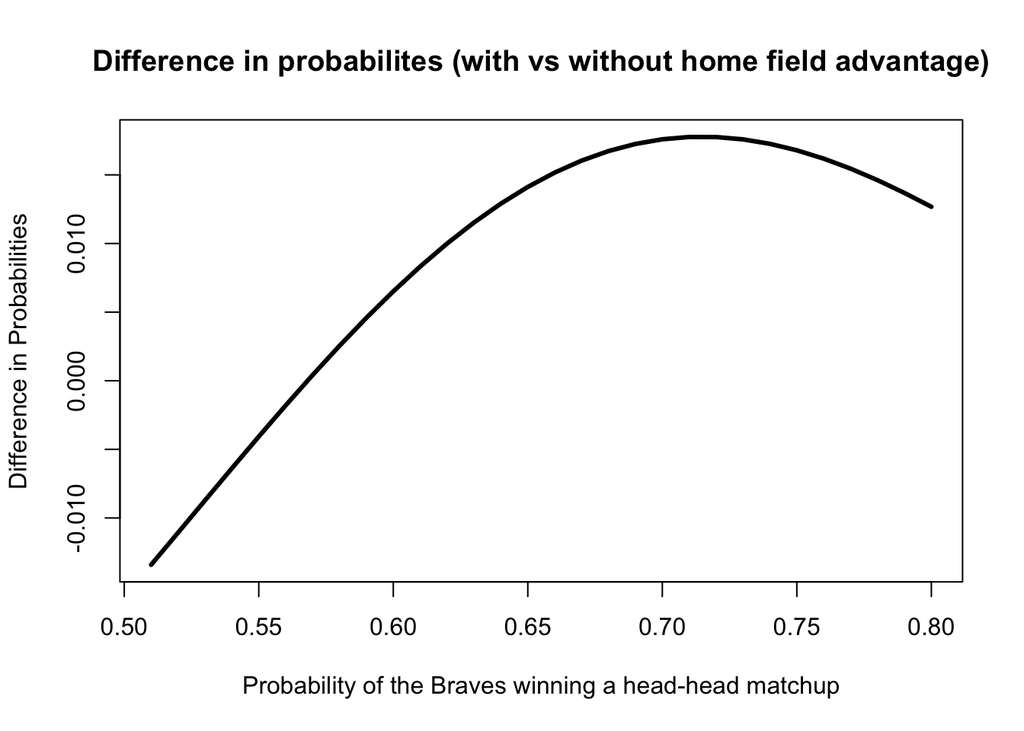

```r
plot(seq(0.51,0.8,0.01),p_with_adv-p_without_adv,type='l',lwd=3,xlab='Probability of the Braves winning a head-head matchup',ylab='Difference in Probabilities',main="Difference in probabilites (with vs without home field advantage)")
```

**Does the difference in probabilites (with vs without home field advantage) depend on the advantage factor?**

The previous assumption is `advantage_multiplier` = 1.1, which leads to a 10% increase for home team. Now let’s set a series of advantage factor, from 1 to 1.5, with break 0.01. Then see if the difference in probabilites depend on the advantage factor.

```r
p_with_adv=rep(NA,50)
p_without_adv=rep(NA,50)
# Get all possible outcomes
for (k in 1:50){
apo <- fread("all-possible-world-series-outcomes.csv")

# Home field indicator
hfi <- c(0,0,1,1,1,0,0) #{NYC, NYC, ATL, ATL, ATL, NYC, NYC}

# P_B
pb <- 0.55
advantage_multiplier <- 1+0.01*k # Set for advantage
pbh <- pb*advantage_multiplier
pba <- 1 - (1 - pb)*advantage_multiplier

# Calculate the probability of each possible outcome
apo[, p := NA_real_] # Initialize new column in apo to store prob
for(i in 1:nrow(apo)){
  prob_game <- rep(1, 7)
  for(j in 1:7){
    p_win <- ifelse(hfi[j], pbh, pba)
    prob_game[j] <- case_when(
        apo[i,j,with=FALSE] == "W" ~ p_win
      , apo[i,j,with=FALSE] == "L" ~ 1 - p_win
      , TRUE ~ 1
    )
  }
  apo[i, p := prod(prob_game)] # Data.table syntax
}


# Sanity check: does sum(p) == 1?
apo[, sum(p)] # This is data.table notation

# Probability of overall World Series outcomes
apo[, sum(p), by=overall_outcome]
overall_win=apo[overall_outcome=="W"]
p_with_adv[k]=sum(overall_win$p)
p_without_adv[k]=pnbinom(3,4,0.55)
}
```

Then we plot the graphic to see the trend:

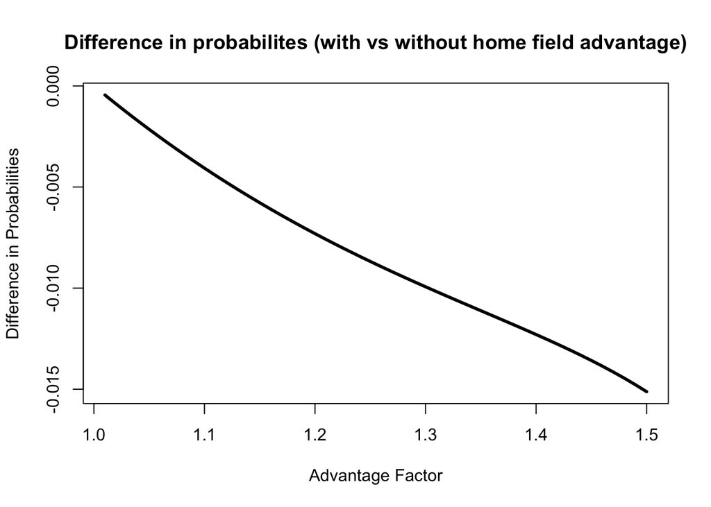

```r
plot(
  seq(1.01, 1.5, 0.01),
  p_with_adv - p_without_adv,
  type = 'l',
  lwd = 3,
  xlab = 'Advantage Factor',
  ylab = 'Difference in Probabilities',
  main = "Difference in probabilites (with vs without home field advantage)"
)
```

From this graphic, we can see the difference in probabilities would decrease from 1 to 1.5. We can also see the difference is negative. Thus, when we turn to absolute value, the absolute value for difference in probabilities will increase as advantage factor increases.

As advantage factor increases, probability of win in Atlanta (P<sub>B</sub><sup>H</sup>=0.55 * advantage) will increases, and probability of win in New York (P<sub>B</sub><sup>A</sup>=1−(1−0.55) * advantage) will decrease. Since Yankees can play one more game at their home field, the probability Braves win world series with home filed advantage will decrease when the advantage factor increases.